# Multi-Matrix Proteomics Analysis

Written by Yuliya V Karpievitch, with contributions from Sufyaan Mohamed and Tim Stuart

2018-04-27

# 1 Introduction

MultiMat is a method that allows one to perform peptide-level differential expression analysis of multiple proteomic datasets simultaneously. MultiMat provides a single p-value and a single effect size estimate for the differences in protein abundances. A test statistic is computed as a sum of F-statistics produced for each individual dataset. A p-value is then estimated via a permutation test as the distribution of the sum of the F-statistics does not have a closed form solution. Simultaneous utilization of all available peptides within proteins in multiple datasets increases statistical power to detect differences among conditions or treatments. In addition, in MultiMat package, we build on our previous research and provide functionality for normalization, model-based imputation of missing peptide abundances and peptide-level differential protein expression analysis [1, 2].

Currently, combined analysis of multiple datasets is limited to utilizing a multi-dataset t-test [3]. Since in proteomics, protein abundances are measured in terms of the constitutive peptides a t-test would require averaging or “rolling-up” the peptide abundances into protein abundances prior to analysis with a multi-dataset t-test. We have previously shown that such reduction in the number of observations leads to the reduced statistical power and reduced ability to detect differentially expressed proteins [1]. MultiMat provides a flexible pipeline from raw peptide abundances to protein quantification for multiple as well as single datasets in bottom-up mass spectrometry-based proteomics studies.

This tutorial will walk the readers through an example analysis of two simulated datasets. For function definitions and descriptions please use “?” command in R.

# 2 Installation

MultiMat can be installed from Bioconductor:

*BiocInstaller::biocLite(“MultiMat”)*

*library(MultiMat)*

Alternatively MultiMat can be installed from GitHub:

*devtools::install_github(“yuliya8k/MultiMat”)*

*library(MultiMat)*

# 3 MultiMat Analysis Pipeline

MultiMat Pipeline includes six steps, which we suggest are performed in the order shown in the flowchart in Figure 1. Individual steps such as normalization, imputation or presence/absence analysis can be skipped but care must be taken to assure that peptides passed into Model-Based Differential Expression Analysis step contain a sufficient number of observations.

The example we provide in this tutorial follows the suggested MultiMat Analysis outline in Figure 1 with additional data visualization that we find useful in proteomics data analysis.

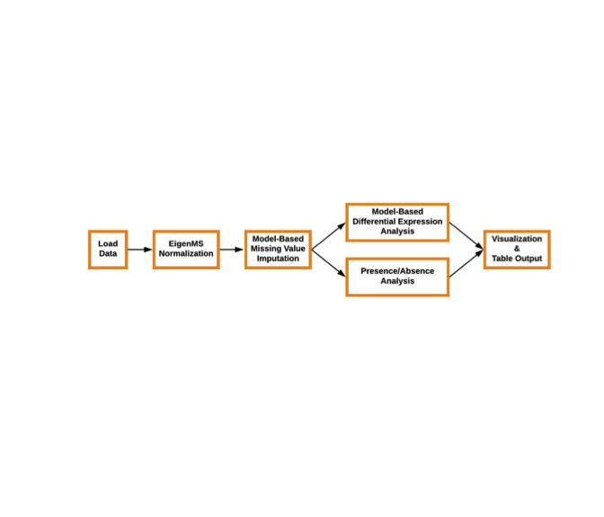

```r
flowchart = imager::load.image('./MultiMatPipelineFlowChart.jpeg')
plot(flowchart, axes=FALSE)
```

**Figure 1. Flow chart of the suggested MultiMat analysis pipeline.**

# 4 EigenMS normalization

The data used in this example is a subset of a proteomics experiment where peptide IDs (sequences) have been shuffled and protein and gene IDs were replaced by fake ‘Prot_#’ name. This document provides an example of the code and data structures that are necessary to run Multi-Matrix analysis, including EigenMS normalization, Model-Based imputation and Multi-Matrix statistical analysis.

For non-proteomics data, such as metabolomics data, 2 columns with identical information can be provided.

Start by loading the data and defining the parameter `prot.info`, a two column data framewith IDs for metabolites or peptides in case of matabolites the 2 columns are identical. For peptides, 1st column must contain unique peptide ID (usually peptide sequences), 2nd column can contain protein IDs, (not used in EigenMS) and any other metadata columns that will be propagated through the analysis pipeline.

## 4.1 Human

Human dataset contains 695 peptides with 13 columns where 6 columns contain intensities and the rest are metadata describing the proteins/peptides. There are six samples with three samples in each of the two treatment groups: CG and mCG.

We replace 0’s with NA’s and log2 transform the intensities as 0’s should not be used in place of the missing observations. Such replacement will severely skew the distribution of intensities and produce invalid differential expression results. For more information see Karpievitch et al. 2009 [1,2].

```r
# Load data for human, then mouse
data("hs_peptides") # loads variable hs_peptides
dim(hs_peptides)  # 695 x 13
```

```
## [1] 695  13
```

```r
intsCols = 8:13   # column indices that contain intensities
m_logInts = make_intencities(hs_peptides, intsCols)

# replace 0's with NA's, NA's are more appropriate for analysis & log2 transform
m_logInts = convert_log2(m_logInts)
metaCols = 1:7 # column indices for metadata such as protein IDs and sequences
m_prot.info = make_meta(hs_peptides, metaCols)

# m_prot.info - 2+ column data frame with peptide IDs and protein IDs
head(m_prot.info)
```

|  | Sequence | MatchedID | ProtID | GeneID | ProtName | ProtIDLong | GeneIDLong |
| --- | --- | --- | --- | --- | --- | --- | --- |
| 1 | CLLAASPENEAGGLKLDGR | 3 | Prot3 | Gene3 | Prot3 Name | Prot3 long | Gene3 long |
| 2 | HNIEGIFTFVDHR | 3 | Prot3 | Gene3 | Prot3 Name | Prot3 long | Gene3 long |
| 3 | RLFSGTQISTIAESEDSQESVDSVTDSQKR | 501 | Prot501 | Gene501 | Prot501 Name | Prot501 long | Gene501 long |
| 4 | LREQYGLGPYEAVTPLTK | 501 | Prot501 | Gene501 | Prot501 Name | Prot501 long | Gene501 long |
| 5 | LINNNPEIFGPLK | 502 | Prot502 | Gene502 | Prot502 Name | Prot502 long | Gene502 long |
| 6 | ENMELEEKEK | 14 | Prot14 | Gene14 | Prot14 Name | Prot14 long | Gene14 long |

```r
dim(m_logInts) # 695 x 6
```

```
## [1] 695   6
```

```r
grps = as.factor(c('CG','CG','CG', 'mCG','mCG','mCG')) # 3 samples for CG & mCG

# check the number of missing values
m_nummiss = sum(is.na(m_logInts))
m_nummiss
```

```
## [1] 1597
```

```r
m_numtot = dim(m_logInts)[1] * dim(m_logInts)[2] #  total # of observations
m_percmiss = m_nummiss/m_numtot  # % missing observations
m_percmiss # 38.29% missing values, representative of the true larger dataset
```

```
## [1] 0.3829736
```

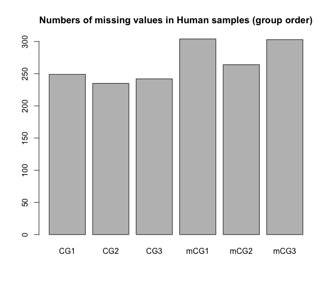

```r
# plot number of missing values for each sample
par(mfcol=c(1,1))
barplot(colSums(is.na(m_logInts)),
        main="Numbers of missing values in Human samples (group order)")
```

**Figure 2. Numbers of missing values in each of the Human samples.** mCG treatment group has more missing values.

```r
# Identify bias trends with eig_norm1()
hs_m_ints_eig1 = eig_norm1(m=m_logInts,treatment=grps,prot.info=m_prot.info)
```

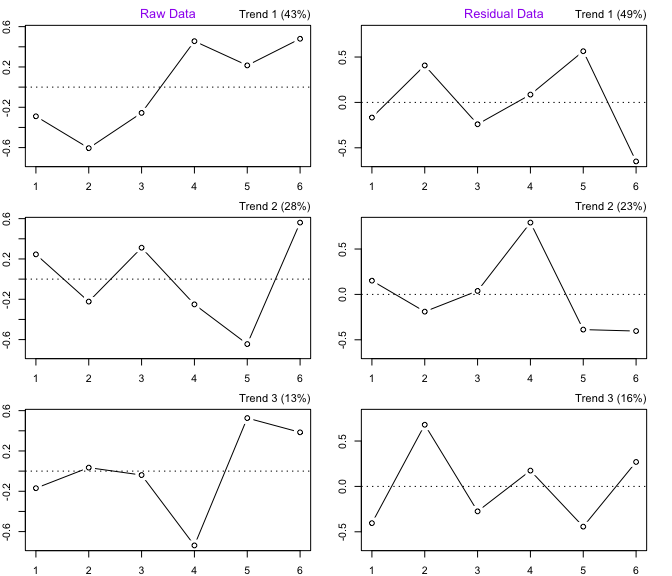

**Figure 3. Eigentrends for raw and residual peptide intensities in Human samples.** Dots at positions 1-6 correspond to the 6 samples. Top trend in the Raw Data (left panel) shows a pattern representative of the differences between the two groups. Top trend in the Residual Data (right panel) shows that sample 2 and 5 have higher similarity to each other, as well as, 1, 3, 4 and 6 whereas in reality samples 1-3 are from the same treatment group and 3-6 are from the other.

```r
# check what is inside
names(hs_m_ints_eig1)
```

```
##  [1] "m"             "treatment"     "my.svd"        "pres"
##  [5] "n.treatment"   "n.u.treatment" "h.c"           "present"
##  [9] "prot.info"     "complete"      "toplot1"       "Tk"
## [13] "ncompl"        "grp"
```

```r
# Our simulated dataset is small, only 1 bias trend was identified in the
# peptides with no missing values. But visually it seems that
# there are at least 2.
hs_m_ints_eig1$h.c # 1
```

```
## [1] 1
```

```r
# Run EigenMS normalization to eliminate 1 bias trend
hs_m_ints_norm_1bt = eig_norm2(rv=hs_m_ints_eig1)
```

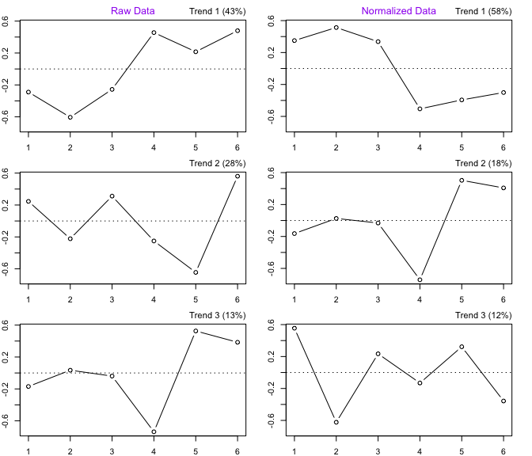

**Figure 4. Eigetrends for raw and normalized peptide intensities in Human samples.** Dots at positions 1-6 correspond to the 6 samples. Top trend in the Normalized Data (right panel) shows a pattern representative of the differences between the two groups (eigen trends can be rotated around the x-axis). There is a 15% increase in percent variance explained by the trend as is indicated by the percentage in the upper right corner. But the next (middle) trend explains 18% of variation, so bias effect of this trend may need to be removed.

```r
# check what is inside
names(hs_m_ints_eig1)
```

```
##  [1] "m"             "treatment"     "my.svd"        "pres"
##  [5] "n.treatment"   "n.u.treatment" "h.c"           "present"
##  [9] "prot.info"     "complete"      "toplot1"       "Tk"
## [13] "ncompl"        "grp"
```

```r
# how many peptides with no missing values (complete) are in the data?
dim(hs_m_ints_eig1$complete)# bias trend identification is based on 196 peptides
```

```
## [1] 196   6
```

Our simulated dataset is small, with only 196 peptides with no missing values, which are used to identify bias trends. Only one bias trend was identified, but visually it seems that there are at least two. So here we manually set h.c to 2 trestnds that are going to be eliminated.

```r
hs_m_ints_eig1$h.c = 2 # visually there are more than 1 bias trend, set to 2
```

```r
hs_m_ints_norm = eig_norm2(rv=hs_m_ints_eig1)
```

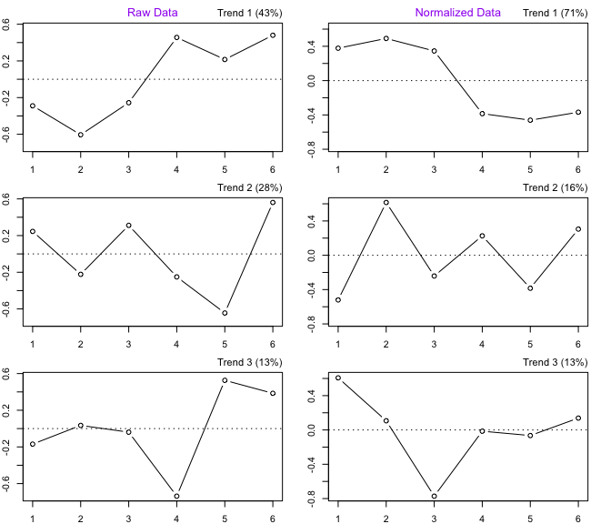

```r
# names(hs_m_ints_norm)
```

**Figure 5. Eigetrends for raw and normalized peptide intensities in Human samples with the effects of two bias trends removed.** Dots at positions 1-6 correspond to the 6 samples. Top trend in the Normalized Data (right panel) shows a pattern representative of the differences between the two groups (eigen trends can be rotated around x-axis).

## 4.2 Mouse

Mouse dataset contains 1102 peptides with 13 columns where 6 column contain intensities and the rest are metadata describing the proteins/peptides.

There are six samples with three samples in each of the two treatment groups: CG and mCG. The data preparation is similar to what we have done for Human data.

```r
data("mm_peptides") # loads variable mm_peptides
dim(mm_peptides)
```

```
## [1] 1102   13
```

```r
dim(mm_peptides) # 1102 x 13
```

```
## [1] 1102   13
```

```r
head(mm_peptides)
```

|  | Sequence | MatchedID | ProtID | GeneID | ProtName | ProtIDLong | GeneIDLong | CG1 | CG2 | CG3 | mCG1 | mCG2 | mCG3 |
| --- | --- | --- | --- | --- | --- | --- | --- | --- | --- | --- | --- | --- | --- |
| 1 | GFAYVQFEDVRDAEDALYNLNRK | 64 | Prot64 | Gene64 | Prot64 Name | Prot64 long | Gene64 long | 3725900 | 11642000 | 4872400 | 0 | 12850000 | 3751700 |
| 2 | SKCEELSSLHGQLKEAR | 61 | Prot61 | Gene61 | Prot61 Name | Prot61 long | Gene61 long | 19699000 | 38055000 | 30661000 | 15896000 | 55187000 | 20356000 |
| 3 | QDAGSEPVTPASLAALQSDVQPVGHDYVEEVR | 61 | Prot61 | Gene61 | Prot61 Name | Prot61 long | Gene61 long | 0 | 0 | 0 | 5277500 | 0 | 38698000 |
| 4 | TGDQEERQDYINLDESEAAAFDDEWRR | 1 | Prot1 | Gene1 | Prot1 Name | Prot1 long | Gene1 long | 0 | 0 | 0 | 0 | 0 | 0 |
| 5 | IPAYFITVHDPAVPPGEDPDGR | 60 | Prot60 | Gene60 | Prot60 Name | Prot60 long | Gene60 long | 9391200 | 0 | 0 | 4689800 | 8305300 | 0 |
| 6 | GGTPGSGAAAAAGSKPPPSSSASASSSSSSFAQQR | 60 | Prot60 | Gene60 | Prot60 Name | Prot60 long | Gene60 long | 0 | 0 | 20406000 | 5809800 | 0 | 0 |

```r
intsCols = 8:13 # may differ for each dataset, users need to adjust
m_logInts = make_intencities(mm_peptides, intsCols)  # reuse the name m_logInts
m_logInts = convert_log2(m_logInts)
metaCols = 1:7
m_prot.info = make_meta(mm_peptides, metaCols)

head(m_prot.info)
```

|  | Sequence | MatchedID | ProtID | GeneID | ProtName | ProtIDLong | GeneIDLong |
| --- | --- | --- | --- | --- | --- | --- | --- |
| 1 | GFAYVQFEDVRDAEDALYNLNRK | 64 | Prot64 | Gene64 | Prot64 Name | Prot64 long | Gene64 long |
| 2 | SKCEELSSLHGQLKEAR | 61 | Prot61 | Gene61 | Prot61 Name | Prot61 long | Gene61 long |
| 3 | QDAGSEPVTPASLAALQSDVQPVGHDYVEEVR | 61 | Prot61 | Gene61 | Prot61 Name | Prot61 long | Gene61 long |
| 4 | TGDQEERQDYINLDESEAAAFDDEWRR | 1 | Prot1 | Gene1 | Prot1 Name | Prot1 long | Gene1 long |
| 5 | IPAYFITVHDPAVPPGEDPDGR | 60 | Prot60 | Gene60 | Prot60 Name | Prot60 long | Gene60 long |
| 6 | GGTPGSGAAAAAGSKPPPSSSASASSSSSSFAQQR | 60 | Prot60 | Gene60 | Prot60 Name | Prot60 long | Gene60 long |

```r
dim(m_logInts)# 1102 x 6
```

```
## [1] 1102    6
```

```r
# check numbers of missing values in Mouse samples
m_nummiss = sum(is.na(m_logInts))
m_nummiss
```

```
## [1] 2698
```

```r
m_numtot = dim(m_logInts)[1] * dim(m_logInts)[2] #  total observations
m_percmiss = m_nummiss/m_numtot  # % missing observations
m_percmiss # 40.8% missing values, representative of the true larger dataset
```

```
## [1] 0.408046
```

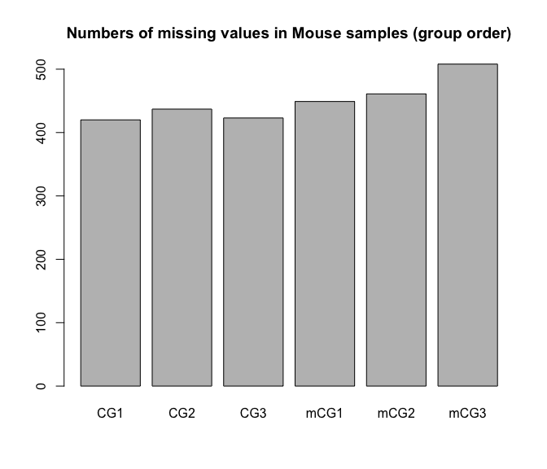

```r
# plot number of missing values for each sample
par(mfcol=c(1,1))
barplot(colSums(is.na(m_logInts)),
        main="Numbers of missing values in Mouse samples (group order)")
```

```r
mm_m_ints_eig1 = eig_norm1(m=m_logInts,treatment=grps,prot.info=m_prot.info)
```

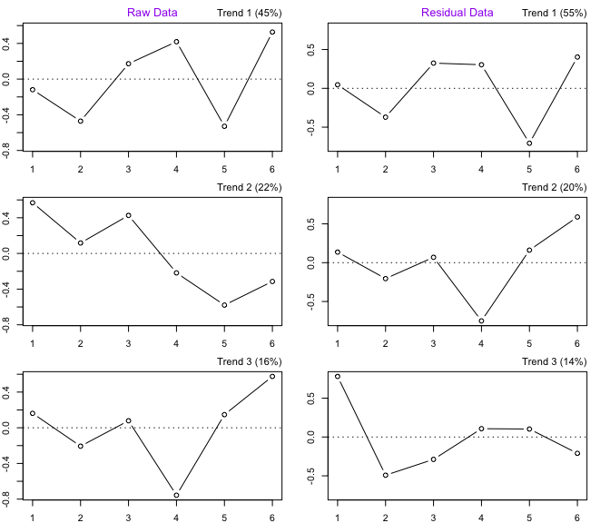

```r
mm_m_ints_eig1$h.c
```

```
## [1] 1
```

```r
mm_m_ints_norm_1bt = eig_norm2(rv=mm_m_ints_eig1)
```

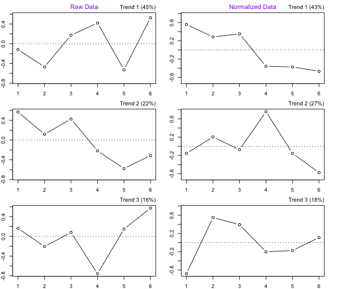

**Figure 8. Eigentrends for raw and normalized peptide intensities in mouse samples with the effects of one bias trends removed.** Dots at positions 1-6 correspond to the 6 samples. Top trend in the Normalized Data Dots at positions 1-6 correspond to the 6 samples. Top trend in the Normalized Data (right panel) shows a pattern representative of the differences between the two groups.

```r
mm_m_ints_eig1$h.c = 2
```

```r
mm_m_ints_norm = eig_norm2(rv=mm_m_ints_eig1)
```

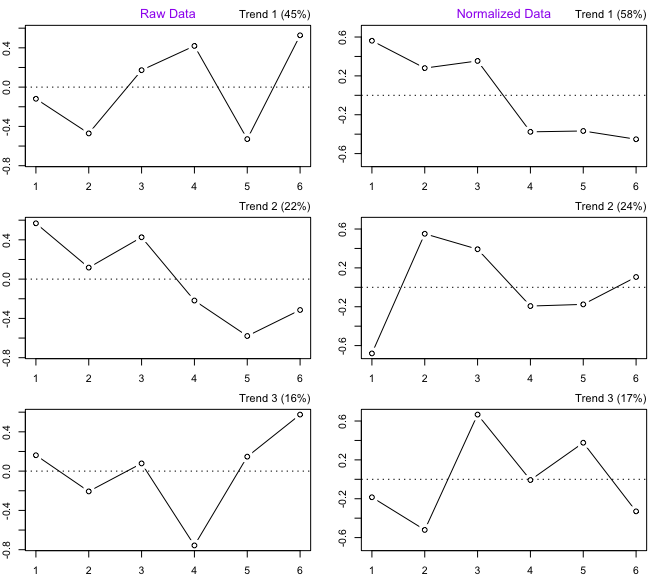

```r
# 190 petides with no missing values were used to id bais trends ($complete)
```

**Figure 9. Eigentrends for raw and normalized peptide intensities in mouse samples with the effects of two bias trends removed.** Dots at positions 1-6 correspond to the 6 samples. Top trend in the Normalized Data (right panel) shows a pattern representative of the differences between the two groups.

```r
length(mm_m_ints_eig1$prot.info$MatchedID)          # 1102 - correct
```

```
## [1] 1102
```

```r
length(hs_m_ints_eig1$prot.info$MatchedID)          # 695 - can normalize all
```

```
## [1] 695
```

```r
length(unique(mm_m_ints_eig1$prot.info$MatchedID) ) # 69
```

```
## [1] 69
```

```r
length(unique(hs_m_ints_eig1$prot.info$MatchedID) ) # 69
```

```
## [1] 69
```

```r
# 787 peptides were normalized, rest eliminated due to low # of observations
dim(mm_m_ints_norm$norm_m)
```

```
## [1] 787   6
```

```r
dim(hs_m_ints_norm$norm_m) # 480 peptides were normalized
```

```
## [1] 480   6
```

# 5 Model-based imputation

Model-based imputation uses a statistical model that accounts for the informative missingness in peptide intensities and provides an unbiased, model-based, protein-level differential expression analysis performed at peptide level [1].

Model-based imputation models two missingness mechanisms, one missing completely at random and the other abundance-dependent. Completely random missingness occurs when the fact that a peptide was unobserved in a sample has nothing to do with its abundance or the abundance of any other peptides. This usually affects a small proportion of the peptides considered in the analysis. From our past experience it is near 5% or all observations. Abundance-dependent missingness occurs due to left-censoring, where a peptide is either not present or is present at too low concentration to be detected by the instrument. In this case, we have partial information for the peptide intensity, in that we know it must be less than the rest of the observed peptide intensities.

## 5.1 Human

We need to set up metadata and intensities to use for the imputation. We will impute based on ProtID - position in the matrix for the Protein Identifier. In this example datasets, ProtID and MatchedID can be used interchangeably.

```r
hs_prot.info = hs_m_ints_norm$normalized[,metaCols]
hs_norm_m =  hs_m_ints_norm$normalized[,intsCols]
head(hs_prot.info)
```

|  | Sequence | MatchedID | ProtID | GeneID | ProtName | ProtIDLong | GeneIDLong |
| --- | --- | --- | --- | --- | --- | --- | --- |
| CLLAASPENEAGGLKLDGR | CLLAASPENEAGGLKLDGR | 3 | Prot3 | Gene3 | Prot3 Name | Prot3 long | Gene3 long |
| HNIEGIFTFVDHR | HNIEGIFTFVDHR | 3 | Prot3 | Gene3 | Prot3 Name | Prot3 long | Gene3 long |
| RLFSGTQISTIAESEDSQESVDSVTDSQKR | RLFSGTQISTIAESEDSQESVDSVTDSQKR | 501 | Prot501 | Gene501 | Prot501 Name | Prot501 long | Gene501 long |
| LINNNPEIFGPLK | LINNNPEIFGPLK | 502 | Prot502 | Gene502 | Prot502 Name | Prot502 long | Gene502 long |
| ENMELEEKEK | ENMELEEKEK | 14 | Prot14 | Gene14 | Prot14 Name | Prot14 long | Gene14 long |
| GHEFYNPQKK | GHEFYNPQKK | 14 | Prot14 | Gene14 | Prot14 Name | Prot14 long | Gene14 long |

```r
head(hs_norm_m)
```

|  | CG1 | CG2 | CG3 | mCG1 | mCG2 | mCG3 |
| --- | --- | --- | --- | --- | --- | --- |
| CLLAASPENEAGGLKLDGR | 24.16344 | 25.11800 | 25.39066 | 24.73530 | 24.47494 | 24.65338 |
| HNIEGIFTFVDHR | 21.81538 | NA | 21.42956 | 21.90027 | 21.74596 | NA |
| RLFSGTQISTIAESEDSQESVDSVTDSQKR | 23.52846 | 22.73723 | 23.53173 | 23.03903 | 23.51463 | 22.95478 |
| LINNNPEIFGPLK | NA | 22.34531 | 21.88714 | NA | 21.09684 | 21.24429 |
| ENMELEEKEK | 27.31511 | 26.85826 | 27.39201 | 27.89371 | 28.18741 | 27.83388 |
| GHEFYNPQKK | 24.69609 | 24.27661 | 24.96221 | 24.42590 | 24.74535 | 24.34182 |

```r
dim(hs_norm_m) # 480 x 6, raw: 695, 215 peptides were eliminated due to lack of
```

```
## [1] 480   6
```

```r
               # observations
length(unique(hs_prot.info$MatchedID)) # 59
```

```
## [1] 59
```

```r
length(unique(hs_prot.info$ProtID))    # 59
```

```
## [1] 59
```

```r
set.seed(1213)
imp_hs = MBimpute(hs_norm_m, grps, prot.info=hs_prot.info, pr_ppos=3,
                  my.pi=0.05, compute_pi=FALSE, sseed=171717) # use default pi
# historically pi=.05 has been representative of the % missing
# observations missing completely at random
```

```r
# check some numbers after the imputation
length(unique(imp_hs$imp_prot.info$MatchedID)) # 59 - MatchedID IDs
```

```
## [1] 59
```

```r
length(unique(imp_hs$imp_prot.info$ProtID))    # 59 - Protein IDs
```

```
## [1] 59
```

```r
length(unique(imp_hs$imp_prot.info$GeneID))    # 59
```

```
## [1] 59
```

```r
dim(imp_hs$imp_prot.info) # 480 x 7 imputed peptides
```

```
## [1] 480   7
```

```r
dim(imp_hs$y_imputed)     # 480 x 6
```

```
## [1] 480   6
```

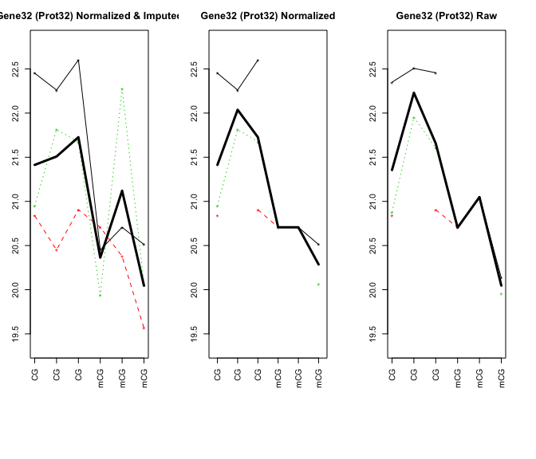

```r
# plot one of the protiens to check normalization and imputation visually
mylabs = c( 'CG','CG','CG', 'mCG','mCG','mCG') # same as grps this is a string
prot_to_plot = 'Prot32' # 43
gene_to_plot = 'Gene32'
plot_3_pep_trends_NOfile(as.matrix(hs_m_ints_eig1$m), hs_m_ints_eig1$prot.info,
                         as.matrix(hs_norm_m), hs_prot.info, imp_hs$y_imputed,
                         imp_hs$imp_prot.info, prot_to_plot, 3, gene_to_plot,
                         4, mylabs)
```

**Figure 10. All peptides within protein Prot32 in raw, normalized, and imputed form.**

## 5.2 Mouse

```r
mm_prot.info = mm_m_ints_norm$normalized[,1:7]
mm_norm_m =  mm_m_ints_norm$normalized[,8:13]
head(mm_prot.info)
```

|  | Sequence | MatchedID | ProtID | GeneID | ProtName | ProtIDLong | GeneIDLong |
| --- | --- | --- | --- | --- | --- | --- | --- |
| GFAYVQFEDVRDAEDALYNLNRK | GFAYVQFEDVRDAEDALYNLNRK | 64 | Prot64 | Gene64 | Prot64 Name | Prot64 long | Gene64 long |
| SKCEELSSLHGQLKEAR | SKCEELSSLHGQLKEAR | 61 | Prot61 | Gene61 | Prot61 Name | Prot61 long | Gene61 long |
| IPAYFITVHDPAVPPGEDPDGR | IPAYFITVHDPAVPPGEDPDGR | 60 | Prot60 | Gene60 | Prot60 Name | Prot60 long | Gene60 long |
| GGTPGSGAAAAAGSKPPPSSSASASSSSSSFAQQR | GGTPGSGAAAAAGSKPPPSSSASASSSSSSFAQQR | 60 | Prot60 | Gene60 | Prot60 Name | Prot60 long | Gene60 long |
| NLGGNYPEK | NLGGNYPEK | 28 | Prot28 | Gene28 | Prot28 Name | Prot28 long | Gene28 long |
| ISCAGPQTYKEHLEGQKHK | ISCAGPQTYKEHLEGQKHK | 53 | Prot53 | Gene53 | Prot53 Name | Prot53 long | Gene53 long |

```r
head(mm_norm_m)
```

|  | CG1 | CG2 | CG3 | mCG1 | mCG2 | mCG3 |
| --- | --- | --- | --- | --- | --- | --- |
| GFAYVQFEDVRDAEDALYNLNRK | 21.99076 | 22.78591 | 22.74153 | NA | 22.68752 | 22.83741 |
| SKCEELSSLHGQLKEAR | 24.24259 | 24.78175 | 25.25876 | 24.56999 | 24.76317 | 24.58578 |
| IPAYFITVHDPAVPPGEDPDGR | 23.13090 | NA | NA | 22.56945 | 22.63033 | NA |
| GGTPGSGAAAAAGSKPPPSSSASASSSSSSFAQQR | NA | NA | 24.28249 | 22.47006 | NA | NA |
| NLGGNYPEK | 24.19505 | 24.89556 | 24.52888 | NA | NA | 24.74703 |
| ISCAGPQTYKEHLEGQKHK | NA | 22.50866 | 23.56617 | 23.18408 | NA | 22.84175 |

```r
dim(mm_norm_m) # 787 x 6, raw had: 1102 peptides/rows
```

```
## [1] 787   6
```

```r
length(unique(mm_prot.info$MatchedID)) # 56
```

```
## [1] 56
```

```r
length(unique(mm_prot.info$ProtID))    # 56
```

```
## [1] 56
```

```r
set.seed(12131)
# as for Human, impute based on ProtID - position in the matrix for the Protein Identifier
imp_mm = MBimpute(mm_norm_m, grps, prot.info=mm_prot.info, pr_ppos=3,
                  my.pi=0.05, compute_pi=FALSE, sseed=17171)
                  # pi =.05 is usually a good estimate
```

Check if returned number of rows corresponds to the same number of rows in normalized data.

```r
dim(imp_mm$imp_prot.info) # 787 x 7 - imputed peptides & 787 were normalized
```

```
## [1] 787   7
```

```r
dim(imp_mm$y_imputed)     # 787 x 6
```

```
## [1] 787   6
```

# 6 Model-Based Differential Expression Analysis

## 6.1 Combined Model-Based Differential Expression Analysis

Multi Matrix analysis is generalizable to 2 or more datasets thus parallel lists are used to store intensities, metadata, and treatment group information. Second column metadata data frame must be a protein identifier that is present in both datasets. In this simulated dataset ProtIDs as well as matchedID, will match across Human and Mouse, in reality, protein IDs will differ, as human and mouse protein IDs are different for the same protein. Gene IDs will generally differ by only by upper vs. lower case, with a few genes having different IDs for the unknown to us reason. Thus when comparing protein abundances across different organisms ProtID is not a good identifier to use across different organisms, instead, protein IDs can be matched based on Ensembl IDs.

We will start by making parallel lists to pass as parameters to teh differential expression function prot_level_multi_part(). Start by dividing the data into a list of proteins that are common to both datasets (can be more than 2) and proteins present only in one or the other (unique to one or the other). Here we will analyze the proteins that were observed only in one of the datasets, Note that “grps”" variable is the same for both simulated dataset here, but for useres number and order of samples ned to checked and grps variable set to the appropriate factors for each dataset. Also note that treatment group order should be the same in all datasets. Do not set groups to

*contr contr contr treat treat treat*

in one sample and

*treat treat treat contr contr contr*

in the other.

```r
# make parallel lists to pass as parameters
mms = list()
treats = list()
protinfos = list()
mms[[1]] = imp_mm$y_imputed
mms[[2]] = imp_hs$y_imputed
treats[[1]] = grps
treats[[2]] = grps

protinfos[[1]] = imp_mm$imp_prot.info
protinfos[[2]] = imp_hs$imp_prot.info

subset_data = subset_proteins(mm_list=mms, prot.info=protinfos, 'MatchedID')
names(subset_data)
```

```
## [1] "sub_mm_list"          "sub_prot.info"        "sub_unique_mm_list"
## [4] "sub_unique_prot.info" "common_list"
```

```r
mm_dd_only = subset_data$sub_unique_prot.info[[1]]
hs_dd_only = subset_data$sub_unique_prot.info[[2]]

ugene_mm_dd = unique(mm_dd_only$MatchedID)
ugene_hs_dd = unique(hs_dd_only$MatchedID)
length(ugene_mm_dd) # 24 - in Mouse only
```

```
## [1] 24
```

```r
length(ugene_hs_dd) # 27 - Human only
```

```
## [1] 27
```

```r
nsets = length(mms)
nperm = 50   # number of permutations should be 500+ for publication quality
```

```r
ptm = proc.time()
comb_MBDE = prot_level_multi_part(mm_list=mms, treat=treats,prot.info=protinfos,
                                  prot_col_name='ProtID', nperm=nperm,
                                  setseed=123, dataset_suffix=c('MM', 'HS'))
proc.time() - ptm  # shows how long it takes to run the test
```

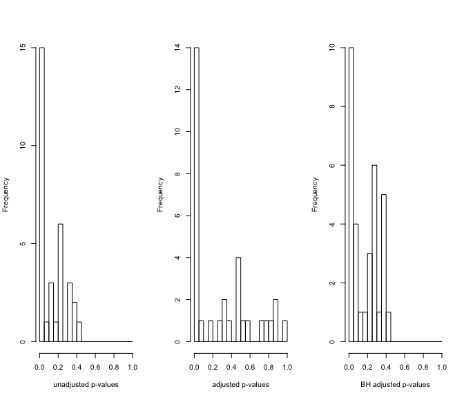

```r
mybreaks = seq(0,1, by=.05)
# adjustment for permutation test is done by stretching out values on the
# interval [0 1]  as expected in a theoretical p-value distribution
par(mfcol=c(1,3)) # always check out p-values
# bunched up on interval [0 .5]
hist(comb_MBDE$P_val, breaks=mybreaks, xlab='unadjusted p-values', main='')
# adjusted p-values look good
hist(comb_MBDE$BH_P_val, breaks=mybreaks, xlab='adjusted p-values', main='')
# bunched up on interval [0 .5]
hist(p.adjust(comb_MBDE$P_val, method='BH'), breaks=mybreaks,
     xlab='BH adjusted p-values', main='')
```

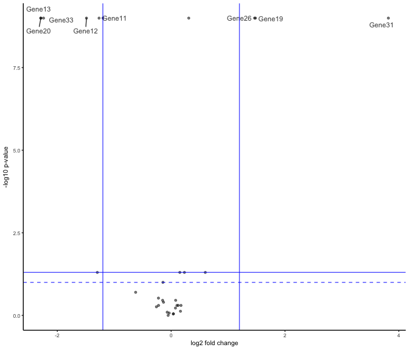

```r
# horizontal streaks correspond to where a permutation test produces 0 or
# very small value, these are reset to improve visualization
par(mfcol=c(1,1)) # Volcano generally look better for larger dataset...
plot_volcano_wLab(comb_MBDE$FC, comb_MBDE$BH_P_val, comb_MBDE$GeneID,
                  FC_cutoff=1.2, PV_cutoff=.05, 'CG vs mCG')
```

**Figure 12. Distribution of p-values and fold changes for combined multi-matrix analysis of Mouse and Human.**

## 6.3 Model-Based Differential Expression Analysis for proteins observed only in Mouse

```r
# subset_data contains "sub_unique_mm_list"  "sub_unique_prot.info" lists
# for each dataset in the order provided to subset function
mms_mm_dd = subset_data$sub_unique_mm_list[[1]] # Mouse
dim(mms_mm_dd)  # 258 x 6,
```

```
## [1] 258   6
```

```r
protinfos_mm_dd = subset_data$sub_unique_prot.info[[1]]

length(unique(protinfos_mm_dd$ProtID))    # 24
```

```
## [1] 24
```

```r
length(unique(protinfos_mm_dd$GeneID))    # 24
```

```
## [1] 24
```

```r
length(unique(protinfos_mm_dd$MatchedID)) # 24
```

```
## [1] 24
```

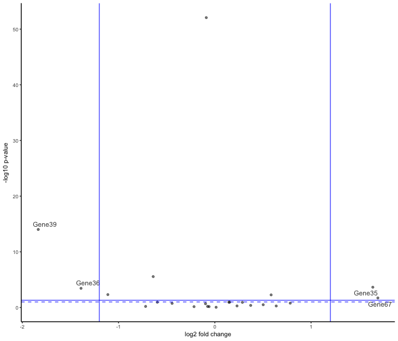

```r
DE_mCG_CG_mm_dd = peptideLevel_DE(mms_mm_dd, grps, prot.info=protinfos_mm_dd,
                                  pr_ppos=2)

# volcano plot
FCval = 1.2 # change this value for alternative fold change cutoff
plot_volcano_wLab(DE_mCG_CG_mm_dd$FC, DE_mCG_CG_mm_dd$BH_P_val,
                  DE_mCG_CG_mm_dd$GeneID, FC_cutoff=FCval,
                  PV_cutoff=.05, 'Mouse specific - CG vs mCG')
```

**Figure 13. Distribution of p-values and fold changes for differential expression analysis in Mouse.**

# 7 Presence-Absence Analysis

## 7.1 Combined Mouse and Human Analysis

In the Presence-Absence Analysis, we use only proteins that are NOT in the normalized data. For example, some peptides may have been eliminated for some proteins due to many missing values, but if some peptides remained in the Model-Based Differential Expression Analysis, we do not analyze a subset of peptides in the Presence-Absence Analysis as we would obtain 2 p-values. We strongly believe that Model-Based Differential Expression Analysis is a more sensitive approach and thus it is a preferred method of analysis for proteins that have sufficient number of observations in both treatment groups.

```r
# make data structures suitable for get_presAbs_prots() function
raw_list = list()
norm_imp_prot.info_list = list()
raw_list[[1]] = mm_m_ints_eig1$m
raw_list[[2]] = hs_m_ints_eig1$m
norm_imp_prot.info_list[[1]] = mm_m_ints_eig1$prot.info
norm_imp_prot.info_list[[2]] = hs_m_ints_eig1$prot.info

protnames_norm_list = list()
protnames_norm_list[[1]] = unique(mm_m_ints_norm$normalized$MatchedID) #56/69
protnames_norm_list[[2]] = unique(hs_m_ints_norm$normalized$MatchedID) #59

presAbs_dd = get_presAbs_prots(mm_list=raw_list,
                               prot.info=norm_imp_prot.info_list,
                               protnames_norm=protnames_norm_list,
                               prot_col_name=2)
```

```
## [1] "Number of peptides normalized: 1072"
## [1] "Number of peptides Pres/Abs: 30"
## [1] "Number of peptides normalized: 663"
## [1] "Number of peptides Pres/Abs: 32"
```

```r
ints_presAbs = list()
protmeta_presAbs = list()
ints_presAbs[[1]] = presAbs_dd[[1]][[1]] # Mouse
ints_presAbs[[2]] = presAbs_dd[[1]][[2]] # HS
protmeta_presAbs[[1]] = presAbs_dd[[2]][[1]]
protmeta_presAbs[[2]] = presAbs_dd[[2]][[2]]

dim(protmeta_presAbs[[2]]) # 32 x 7 peptides
```

```
## [1] 32  7
```

```r
length(unique(protmeta_presAbs[[2]]$MatchedID))  # 10 - proteins
```

```
## [1] 10
```

```r
dim(protmeta_presAbs[[1]]) # 30 x 7 peptides
```

```
## [1] 30  7
```

```r
length(unique(protmeta_presAbs[[1]]$MatchedID))  # 13 - proteins
```

```
## [1] 13
```

```r
 # grps are the same for all analyses
subset_presAbs = subset_proteins(mm_list=ints_presAbs,
                                 prot.info=protmeta_presAbs,'MatchedID')
names(subset_presAbs)
```

```
## [1] "sub_mm_list"          "sub_prot.info"        "sub_unique_mm_list"
## [4] "sub_unique_prot.info" "common_list"
```

```r
dim(subset_presAbs$sub_unique_prot.info[[1]])
```

```
## [1] 17  7
```

```r
dim(subset_presAbs$sub_unique_prot.info[[2]])
```

```
## [1] 14  7
```

```r
dim(subset_presAbs$sub_prot.info[[1]])
```

```
## [1] 13  7
```

```r
dim(subset_presAbs$sub_prot.info[[2]])
```

```
## [1] 18  7
```

```r
nperm = 50  # set to 500+ for publication
ptm = proc.time()
presAbs_comb=prot_level_multiMat_PresAbs(mm_list=subset_presAbs$sub_mm_list,
                                         treat=treats,
                                         prot.info=subset_presAbs$sub_prot.info,
                                         prot_col_name='MatchedID', nperm=nperm,
                                         setseed=123372,
                                         dataset_suffix=c('MM', 'HS') )
proc.time() - ptm
```

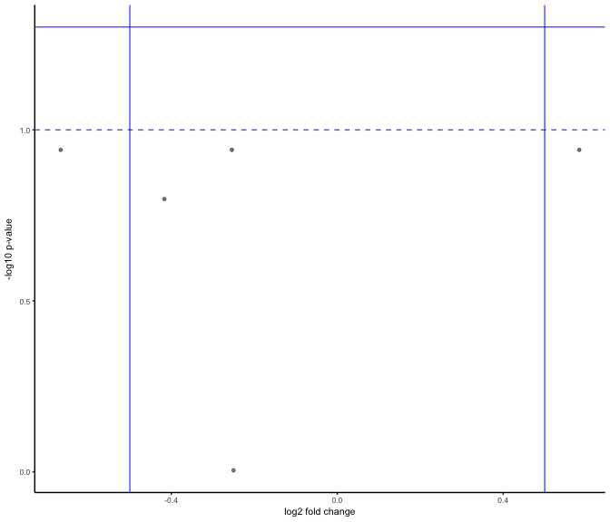

```r
plot_volcano_wLab(presAbs_comb$FC, presAbs_comb$BH_P_val, presAbs_comb$GeneID,
                  FC_cutoff=.5, PV_cutoff=.05, 'Combined Pres/Abs CG vs mCG')
```

**Figure 14. Distribution of p-values and fold changes for differential expression in the combined analysis of Human and Mouse data in CG context.**

```r
# just checking the numbers here
dim(subset_presAbs$sub_unique_mm_list[[1]])
```

```
## [1] 17  6
```

```r
dim(subset_presAbs$sub_unique_mm_list[[2]])
```

```
## [1] 14  6
```

```r
unique(subset_presAbs$sub_unique_prot.info[[1]]$ProtID)# 8
```

```
## [1] Prot55 Prot58 Prot45 Prot37 Prot46 Prot69 Prot63 Prot62
## 69 Levels: Prot1 Prot10 Prot11 Prot12 Prot13 Prot14 Prot15 ... Prot9
```

```r
unique(subset_presAbs$sub_unique_prot.info[[2]]$ProtID)# 5
```

```
## [1] Prot523 Prot525 Prot527 Prot529 Prot530
## 69 Levels: Prot1 Prot10 Prot11 Prot12 Prot13 Prot14 Prot15 ... Prot9
```

## 7.2 Presence/Absence analysis for proteins found only in Mouse

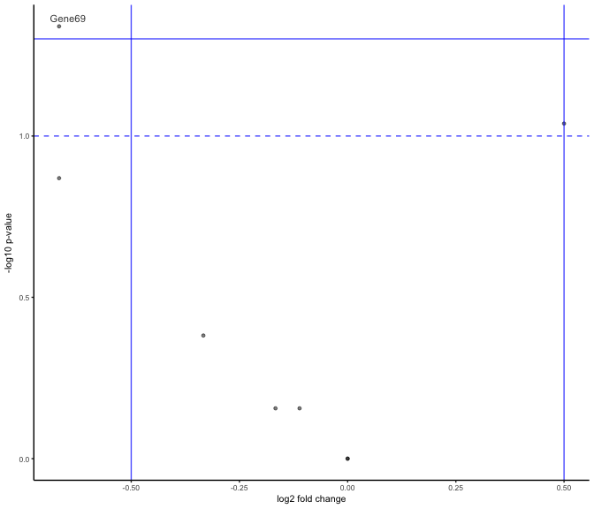

```r
mm_presAbs = peptideLevel_PresAbsDE(subset_presAbs$sub_unique_mm_list[[1]],
                                    treats[[1]],
                                    subset_presAbs$sub_unique_prot.info[[1]],
                                    pr_ppos=3)

plot_volcano_wLab(mm_presAbs$FC, mm_presAbs$BH_P_val, mm_presAbs$GeneID,
                  FC_cutoff=.5, PV_cutoff=.05, 'MM Pres/Abs CG vs mCG')
```

**Figure 15. Distribution of p-values and fold changes for the presence/absence analysis in Mouse data in CG context.**

## 7.3 Presence/Absence analysis for proteins found only in Human

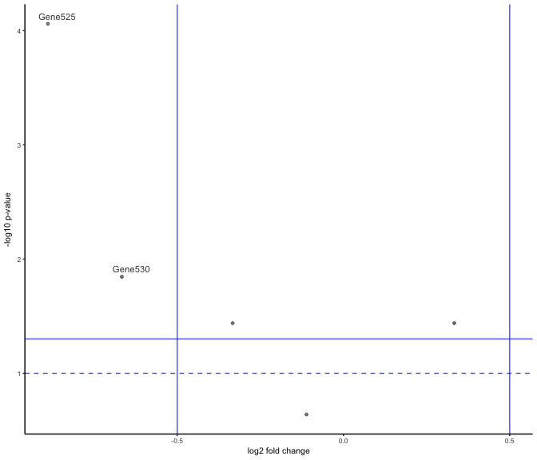

```r
hs_presAbs = peptideLevel_PresAbsDE(subset_presAbs$sub_unique_mm_list[[2]],
                                    treats[[2]],
                                    subset_presAbs$sub_unique_prot.info[[2]],
                                    pr_ppos=3)

plot_volcano_wLab(hs_presAbs$FC, hs_presAbs$BH_P_val, hs_presAbs$GeneID,
                  FC_cutoff=.5, PV_cutoff=.05, 'HS Pres/Abs CG vs mCG')
```

**Figure 16. Distribution of p-values and fold changes for the presence/absence analysis in Human data in CG context.**

# 8 References

1. Karpievitch, Y.V., et al., A statistical framework for protein quantitation in bottom-up MS-based proteomics. Bioinformatics, 2009. 25(16): p. 2028-34.
2. Karpievitch, Y.V., et al., Normalization of peak intensities in bottom-up MS-based proteomics using singular value decomposition. Bioinformatics, 2009. 25(19): p. 2573-80.
3. Taylor, S.L., et al., Multivariate two-part statistics for analysis of correlated mass spectrometry data from multiple biological specimens. Bioinformatics, 2017. 33(1): p. 17-25.